# Engagement Levels for Users with Facebook Container

Ben Miroglio

3/26/2019

This analysis is in response to [Bug 1538406: Measure engagement of Facebook Container addon users](https://bugzilla.mozilla.org/show_bug.cgi?id=1538406).

# TL;DR

- While the Facebook container [DAU/WAU/MAU charts](https://metrics.mozilla.com/protected/bmiroglio/firefox-addons/_site/facetainer.html) are ever-increasing, still only 0.4% of users have the extension.
- The 0.4% of users that have Facebook Container, on average, report 47%, 53% and 83% **more** Active Hours, Total URI counts and SAP searches, respectively, than users from the general Firefox population.
- The 0.4% of users that have Facebook Container, on average, report 17% and 7% **less** Ad Impressions and Ad Clicks, respectively, than users from the general Firefox population.
- **This report does not claim that the differences we see for users with Facebook Container are a result of installing Facebook Container. All we can say is that users with the extension happen to be more (or less) engaged when considering certain metrics.**
  - Users with Facebook Container are likely more engaged to begin with, however we do not investigate this here. This is a classic correlation vs. causation issue. All this report can offer is a correlation. While there are many avenues worth exploring here, the time-sensitive nature of this request limit the depth of the report.

# Data

This analysis uses a 1% sample of Release 65+ Firefox from 2019-02-01 to 2019-02-21. ETL code is [here](https://dbc-caf9527b-e073.cloud.databricks.com/#notebook/93692/command/94130).

# Analysis Results

All metrics below are calculated **daily user averages.** That is to say: we take the average value for a metric per-user-per-day, and then take one more average creating what can be thought of as the Mean(Average Daily value Per User) for each metric. This helps give a more reliable picture when faced with outliers.

As you move through this section, each subsequent table/chart is showing a slightly more detailed view of the same information.

### Average Daily Percent Differences

Table 1 below shows the average daily percent differences in the metrics in question for users with Facebook Container compared to both the general Firefox Release population and users with self-installed add-ons. **Users with Facebook container consistently report higher engagement numbers for all metrics except the ones pertaining to ads**.

|  | Metric | % Difference From General Population | % Difference from Add-ons Users |
| --- | --- | --- | --- |
| 1 | Active Hours | 0.471170764302207 | 0.375598229541104 |
| 2 | Total URI Count | 0.529639055044247 | 0.430760829626776 |
| 3 | SAP | 0.825489539443653 | 0.67552526261593 |
| 4 | Ad Impressions | -0.170274527849076 | -0.123109834113194 |
| 5 | Ad Clicks | -0.0742965511541826 | -0.0229312787851344 |
| 6 | Ad Click Through Rate | -0.145270175303596 | -0.111567046517687 |

### Average Daily Values

The following table/chart show the average daily values for 6 different “Sub Populations”:

- **General Population**: the population for this analysis (not a sub-population)
- **No Add-ons**: Users without self-installed Add-ons
- **Any Add-ons**: Users with 1+ self-installed Add-ons
- **uBlock Origin**: Users with the uBlock Origin extension
- **Ghostery**: Users with the Ghostery extension
- **Facebook Container**: Users with the Facebook Container extension

uBlock Origin and Ghostery are included for comparison since they in the same vein category-wise as Facebook Container. To put these various sub-populations into context, Table 2 below the percentage of users that belong to each sub-group. Some of these groups are overlapping, therefore the percentages won’t sum to 100%. Note that these percentages are over a 3 week period, and will likely differ slightly from something you’ve seen before.

|  | Sub-Population | % Users |
| --- | --- | --- |
| 1 | No Add-ons | 0.728656063237368 |
| 2 | Any Add-on | 0.271343936762632 |
| 3 | uBlock Origin | 0.0283527586853541 |
| 4 | Ghostery | 0.00660166409836199 |
| 5 | Facebook Container | 0.003790287731657 |

Looking below at Table 3, **users with Facebook container report 1.22 average daily active hours, 201 average daily URIs, etc**. As observed in Table 1, these metrics are consiently higher for Facebook Container users except for those involving ads.

|  | Sub-Population | Active Hours | Total URI Count | SAP | Ad Impressions | Ad Clicks | Ad Click Through Rate |
| --- | --- | --- | --- | --- | --- | --- | --- |
| 1 | General Population | 0.827200227930556 | 131.51549161 | 2.31283253 | 0.09027463 | 0.02528933 | 0.00831054626663855 |
| 2 | No Add-ons | 0.755371036805556 | 120.10028989 | 2.05677445 | 0.09647719 | 0.02690345 | 0.00871048255118779 |
| 3 | Any Add-on | 0.884671676236111 | 140.60437506 | 2.51983762 | 0.08541909 | 0.02395985 | 0.00799528172134233 |
| 4 | uBlock Origin | 0.949848928180556 | 150.45952083 | 2.83561625 | 0.10733323 | 0.02862739 | 0.00993926869716029 |
| 5 | Ghostery | 0.961640988263889 | 139.96246059 | 3.26947973 | 0.03139356 | 0.00890348 | 0.00305231452424534 |
| 6 | Facebook Container | 1.21695279155556 | 201.17123231 | 4.22205159 | 0.07490316 | 0.02341042 | 0.00710327175361532 |

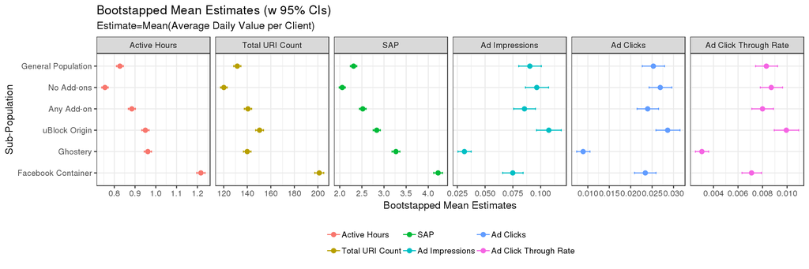